# **Project 2**, APS1070 Fall 2023

**Anomaly Detection Algorithm using Gaussian Mixture Model**

**Deadline: OCT 27, 11 PM**

**Academic Integrity**

This project is individual - it is to be completed on your own. If you have questions, please post your query in the APS1070 Piazza Q&A forums (the answer might be useful to others!).

Do not share your code with others, or post your work online. Do not submit code that you have not written yourself. Students suspected of plagiarism on a project, midterm or exam will be referred to the department for formal discipline for breaches of the Student Code of Conduct.

Please fill out the following:

- Name: **Yuchen Ding**
- Student Number: **1010743420**

### How to submit **(HTML + IPYNB)**

1. Download your notebook: `File -> Download .ipynb`
2. Click on the Files icon on the far left menu of Colab
3. Select & upload your `.ipynb` file you just downloaded, and then obtain its path (right click) (you might need to hit the Refresh button before your file shows up)
1. execute the following in a Colab cell:

   ```
   %%shell
   jupyter nbconvert --to html /PATH/TO/YOUR/NOTEBOOKFILE.ipynb
   ```

2. An HTML version of your notebook will appear in the files, so you can download it.
3. Submit **both** `HTML` and `IPYNB` files on Quercus for grading.

Ref: https://stackoverflow.com/a/64487858

## **Part 1: Getting started [1.5 Marks]**

We are going to work with a [credit card fraud detection](https://www.kaggle.com/datasets/mlg-ulb/creditcardfraud) dataset, consisting of transactions made by credit cards in September 2013 by European cardholders. The dataset contains only numerical input variables (`V1`, `V2`, … `V28`) which are the principal components obtained with PCA transformation (PCA will the introduced later in this course), due to confidentiality issues. The only features which have not been transformed with PCA are `Time` (seconds elapsed between each transaction and the first transaction in the dataset) and `Amount` (transaction Amount).\ This dataset contains 30 key features, which are not directly interpretable but contain meaningful information about the dataset. Load the dataset in CSV file using Pandas. The dataset is called `creditcard.csv`. Print out the first few columns of the dataset.

- How many rows are there? **284807_** **[0.1]**
- Which column contains the targets? 'Class' **[0.1]**
- What is the meaning of target values?**_** **[0.2]**

```python
pip install wget
```

```
  Preparing metadata (setup.py) ... done
```

```python
import wget

wget.download('https://raw.githubusercontent.com/Sabaae/Dataset/master/creditcard.csv')
```

```
'creditcard.csv'
```

```python
import pandas as pd
import numpy as np
import matplotlib.pyplot as plt
import seaborn as sns
from sklearn.model_selection import train_test_split
from sklearn.preprocessing import StandardScaler
```

```python
### YOUR CODE HERE ###

df = pd.read_csv('creditcard.csv')
print(df.head())

print()
# Find the number of rows
print(f'The number of rows is: {df.shape[0]}')

# Locate the column that contains target values
print('The target value column is "Class"')
```

```
   Time        V1        V2        V3        V4        V5        V6        V7  \
0   0.0 -1.359807 -0.072781  2.536347  1.378155 -0.338321  0.462388  0.239599
1   0.0  1.191857  0.266151  0.166480  0.448154  0.060018 -0.082361 -0.078803
2   1.0 -1.358354 -1.340163  1.773209  0.379780 -0.503198  1.800499  0.791461
3   1.0 -0.966272 -0.185226  1.792993 -0.863291 -0.010309  1.247203  0.237609
4   2.0 -1.158233  0.877737  1.548718  0.403034 -0.407193  0.095921  0.592941

         V8        V9  ...       V21       V22       V23       V24       V25  \
0  0.098698  0.363787  ... -0.018307  0.277838 -0.110474  0.066928  0.128539
1  0.085102 -0.255425  ... -0.225775 -0.638672  0.101288 -0.339846  0.167170
2  0.247676 -1.514654  ...  0.247998  0.771679  0.909412 -0.689281 -0.327642
3  0.377436 -1.387024  ... -0.108300  0.005274 -0.190321 -1.175575  0.647376
4 -0.270533  0.817739  ... -0.009431  0.798278 -0.137458  0.141267 -0.206010

        V26       V27       V28  Amount  Class
0 -0.189115  0.133558 -0.021053  149.62      0
1  0.125895 -0.008983  0.014724    2.69      0
2 -0.139097 -0.055353 -0.059752  378.66      0
3 -0.221929  0.062723  0.061458  123.50      0
4  0.502292  0.219422  0.215153   69.99      0

[5 rows x 31 columns]

The number of rows is: 284807
The target value column is "Class"
```

**Meaning of target values: In this credit card dataset, the objective is to classify whether a transaction is fraululent or not given the features of v1-v28, time, and transaction amount. For example, the target value would be 1(fraudulent transaction detected) and 0(no fraudulent transaction found)**

It's important to know how many examples we have for each class when we work with a new dataset.

- What is the percentage of entries in the dataset for each class? **_** **[0.1]**
- Is this data considered balanced or unbalanced? Why is this the case?**_** **[0.1]**
- Why is balance/imbalance important? How might this class ditribution affect a KNN classifier for example, which we explored in Project 1? **_** **[0.5]**
- What metrics should we use to evaluate a model in such cases **_** **[0.2]**

```python
### YOUR CODE HERE ###

# Find the percentage of entries for each class
n=0
m=0
for i in df['Class']:
  if i==0:
    n+=1
  elif i==1:
    m+=1
  else:
    print(f'anomaly value {i} found')

percentage_n = (n/(n+m))*100
percentage_m = 100 - percentage_n
print(f'The percentage for first entry 1 in class is {percentage_n}%, \nThe second entry 0 in class is {percentage_m}% ')
```

```
The percentage for first entry 1 in class is 99.82725143693798%,
The second entry 0 in class is 0.17274856306201514%
```

**The data is considered unbalanced because over 99.82% of the total transaction are allocated to one single class 0(not fraudulent), and the remaining tiny portion is for class 1(fraudulent). Although it is normal to have this highly differnt portion in real world, the extreme bias would affect the performance of machine learning algorithm**

**The reason that balance/imbalance is important is that whether the data is balanced will affect the machine learning algorithm performance because the extreme bias will always result in a high testing accuracy(which is meaningless) and fraudulent data would not be emphasized.**

**By comparing with KNN classifier in project 1, this unbalanced target value distribution may cause biased neighborhood boundry determinination, and thus cause the model more easily to become underfit or overfit. As most of data are non-fraud, so when it comes to prediction, it is more likely that a test point is classified as non-fraud given that it is actually fraud transaction, which is bad performance on identifying minority classes.**

**To evaluate this model, we can use confusion matrix with identification of tp,fp,tn,fn to classify the predictions and actual data. We can also use precision, recall, F1 score after calculating the confusion matrix as well as ROC curve and AUC to determine the model performance under different parameter or feature selections.**

Next, split the dataset into a training (70%), validation (15%) and testing set (15%). Set the random state to 0. **[0.2]**

Make sure to separate out the column corresponding to the targets.

```python
### Split the data  ###

X = df.drop(columns=['Class','Amount','Time'])
y = df['Class']

# Split into training (70%) and temporary (30%) sets
X_train, X_temp, y_train, y_temp = train_test_split(X, y, test_size=0.30, random_state=0)

# Split the temporary set into validation and testing sets (each 15% of the original data)
X_val, X_test, y_val, y_test = train_test_split(X_temp, y_temp, test_size=0.50, random_state=0)
```

```python
features=[f for f in df.columns if f not in ['Class', 'Time']]
features=[f for f in df.columns if not 'Class' in f]
```

Now, let's take a look at the difference in distribution for all variables between non-fraudulent and fraudulent credit card transactions:

```
V1
V2
V3
V4
V5
V6
V7
V8
V9
V10
V11
V12
V13
V14
V15
V16
V17
V18
V19
V20
V21
V22
V23
V24
V25
V26
V27
V28
```

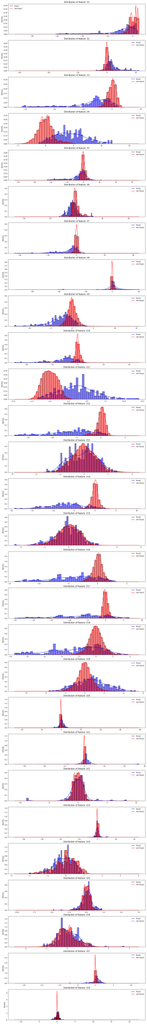

```python
import matplotlib.gridspec as gridspec
features=[f for f in df.columns if f not in ['Class', 'Time','Amount']]
nplots=np.size(features)
plt.figure(figsize=(15,4*nplots))
gs = gridspec.GridSpec(nplots,1)
for i, feat in enumerate(features):
    print(feat)
    ax = plt.subplot(gs[i])
    sns.histplot(X_train[feat][y_train==1], stat="density", kde=True, color="blue", bins=50)
    sns.histplot(X_train[feat][y_train==0], stat="density", kde=True, color="red", bins=50)
    ax.legend(['fraud', 'not-fraud'],loc='best')
    ax.set_xlabel('')
    ax.set_title('Distribution of feature: ' + feat)
```

Explain how these graphs could provide meaningful information about anomaly detection using a gaussian model. **[0.5]**

**Given the histogram for each feature categorized by fraud and non-fraud class, we can easily locate the distribution for these two classes in every feature. With data visualizations, we now have a overview of gaussian model parameters such as mean and variance for each feature. We can also find out which feature distribution is convex(only one peak) and non-convex(with multiple peaks). To deal with non-convex distribution, we may implement gaussian mixture models.**

**It also helps determine which features we should pick to build the gaussian model to ensure the highest performance. For example, if the fraud distribution and non-fraud distribution is not located/centralized in the same interval,it means this feature is helpful to identify the classes and is useful to fit the model. If the distribution of two or more features have extreme overlap so that the peak interval is disrupted and thus affect the anomaly detection. All in all, I think feature v3,v4,v10,v11,v12,v14,v16,v17 distribution is straightforward and should be considered for future model input**